# **Panorama da inflação**

Os principais índices de inflação do Brasil, apontam em agosto de 2006 um avanço da inflação de em média **0.13%**. Com esse resultado, no ano a inflação acumula uma variação média positiva de **1.32%**, e em 12 meses uma variação média acumulada de **3.04%**.

[output not shown]

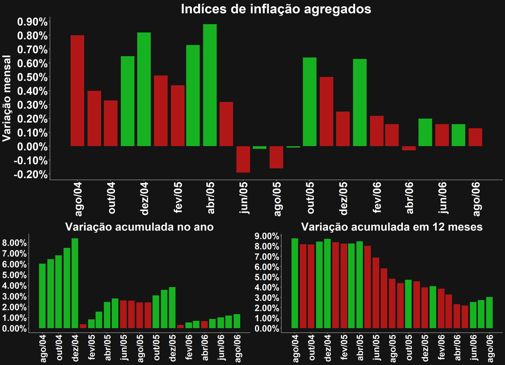

Índices selecionados para a média: IPCA, INPC e IGP-M.

# IPCA

|  | 08/2005 | 07/2006 | 08/2006 |
| --- | --- | --- | --- |
| Variação mensal | 0.17% | 0.19% | 0.05% |
| Variação acumulada no ano | 3.59% | 1.73% | 1.78% |
| Variação acumulada em 12 meses | 6.02% | 3.97% | 3.84% |

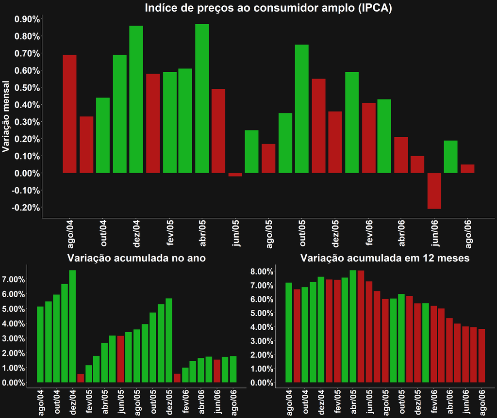

Os grupos que tiveram maior resultado positivo foram Despesas pessoais (0.96%) e Saúde e cuidados pessoais (0.2%), e negativo Transportes (-0.32%) e Comunicação (-0.3%).

|  | Variação mensal | Variação acumulada no ano | Peso mensal |
| --- | --- | --- | --- |
| Alimentação e bebidas | 0.07% | -1.16% | 20.27% |
| Habitação | 0.11% | 2.32% | 13.68% |
| Artigos de residência | -0.14% | -2% | 4.83% |
| Vestuário | 0.09% | 2.23% | 6.5% |
| Transportes | -0.32% | 2.09% | 21% |
| Saúde e cuidados pessoais | 0.2% | 4.84% | 10.78% |
| Despesas pessoais | 0.96% | 4.21% | 9.3% |
| Educação | -0.02% | 5.86% | 7.11% |
| Comunicação | -0.3% | -0.05% | 6.54% |

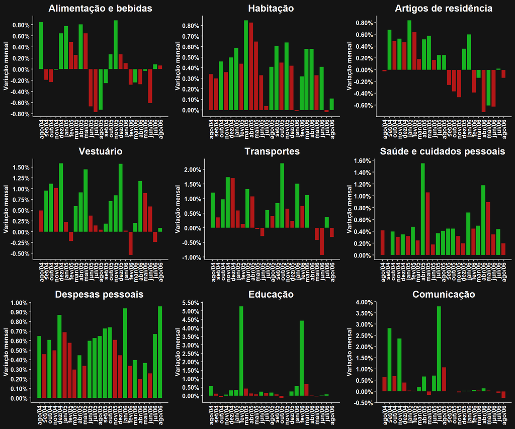

A nível de sub-itens os que mais influenciaram positivamente no resultado em relação ao seu peso foram Empregado doméstico (2.26%%) e Mamão (43.66%%), e negativamente Batata-inglesa (-14.69%%) e Telefone fixo (-0.54%%).

|  | Variação mensal | Variação acumulada no ano | Peso mensal |
| --- | --- | --- | --- |
| Mamão | 43.66% | 92.5% | 0.09% |
| Empregado doméstico | 2.26% | 3.47% | 2.8% |
| Plano de saúde | 0.76% | 1.56% | 3.18% |
| Aluguel residencial | 0.42% | 0.62% | 2.69% |

|  | Variação mensal | Variação acumulada no ano | Peso mensal |
| --- | --- | --- | --- |
| Gasolina | -0.4% | 0.41% | 4.8% |
| Telefone fixo | -0.54% | -0.81% | 3.77% |
| Automóvel novo | -0.6% | -1.02% | 3.03% |
| Batata-inglesa | -14.69% | -14.6% | 0.17% |

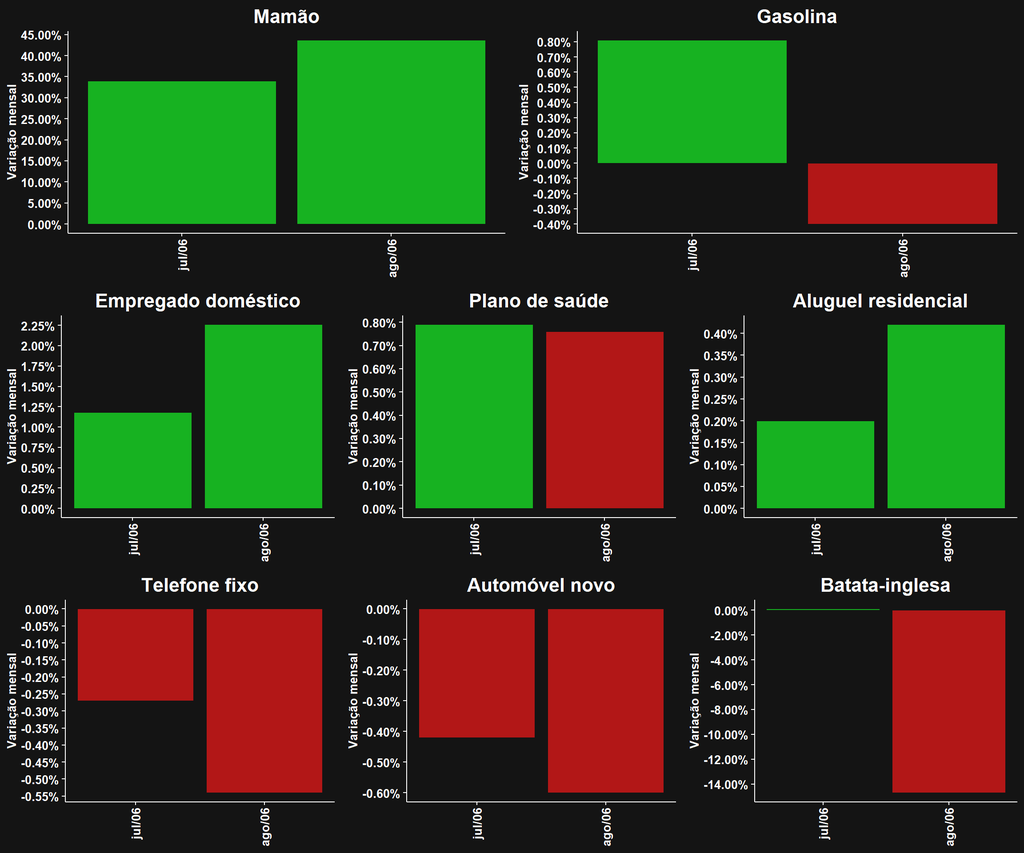

# INPC

O Indíce Nacional de Preços ao Consumidor (INPC) variou -0.02% em agosto, valor inferior ao mesmo período do ano anterior quando apresentou uma taxa de 0%. Com esse resultado o indíce acumula no ano uma variação positiva de 1.16%, e em 12 meses uma variação positiva de 2.85%.

|  | 08/2005 | 07/2006 | 08/2006 |
| --- | --- | --- | --- |
| Variação mensal | 0% | 0.11% | -0.02% |
| Variação acumulada no ano | 3.31% | 1.18% | 1.16% |
| Variação acumulada em 12 meses | 5.01% | 2.87% | 2.85% |

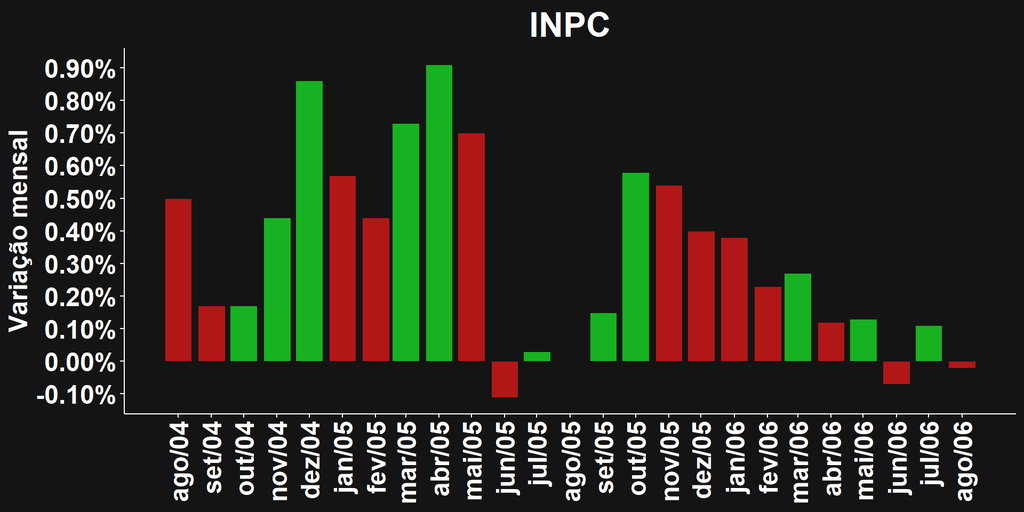

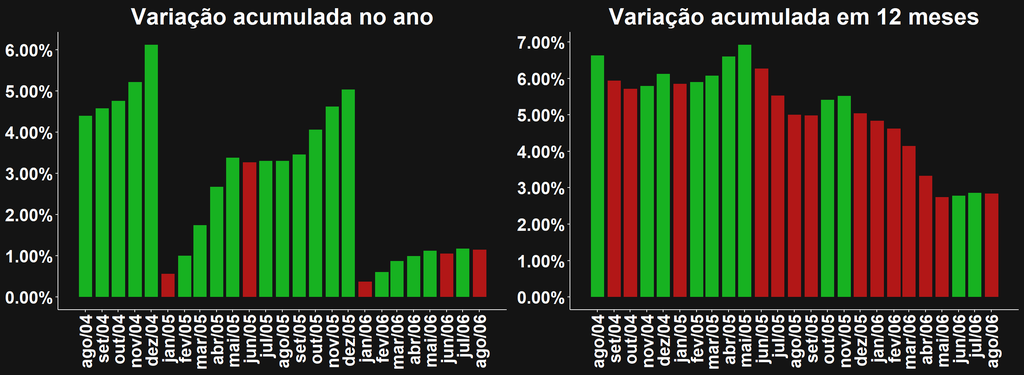

# IGP-M

O Indíce Geral de Preços de Mercado (IGP-M) variou 0.37% em agosto, valor superior ao mesmo período do ano anterior quando apresentou uma taxa de -0.65%. Com esse resultado o indíce acumula no ano uma variação positiva de 1.03%, e em 12 meses uma variação positiva de 2.43%.

|  | 08/2005 | 07/2006 | 08/2006 |
| --- | --- | --- | --- |
| Variação mensal | -0.65% | 0.18% | 0.37% |
| Variação acumulada no ano | 0.35% | 0.66% | 1.03% |
| Variação acumulada em 12 meses | 3.43% | 1.39% | 2.43% |

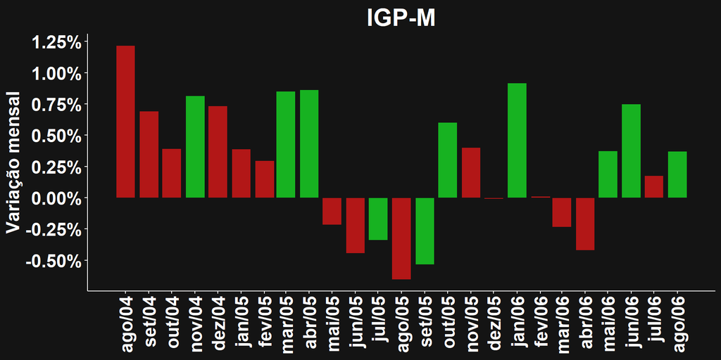

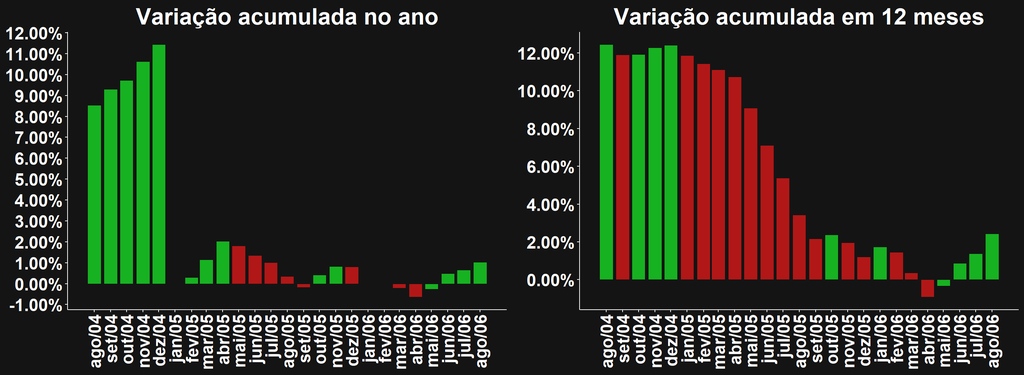

# IGP-DI

O Indíce Geral de Preços - Disponibilidade Interna (IGP-DI) variou 0.41% em agosto, valor superior ao mesmo período do ano anterior quando apresentou uma taxa de -0.79%. Com esse resultado o indíce acumula no ano uma variação positiva de 1.14%, e em 12 meses uma variação positiva de 2.78%.

|  | 08/2005 | 07/2006 | 08/2006 |
| --- | --- | --- | --- |
| Variação mensal | -0.79% | 0.17% | 0.41% |
| Variação acumulada no ano | -0.01% | 0.72% | 1.14% |
| Variação acumulada em 12 meses | 2.71% | 1.56% | 2.78% |

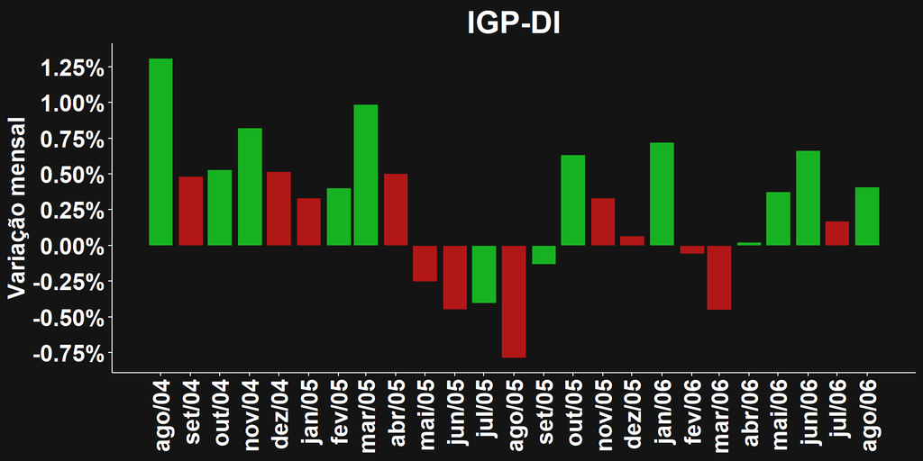

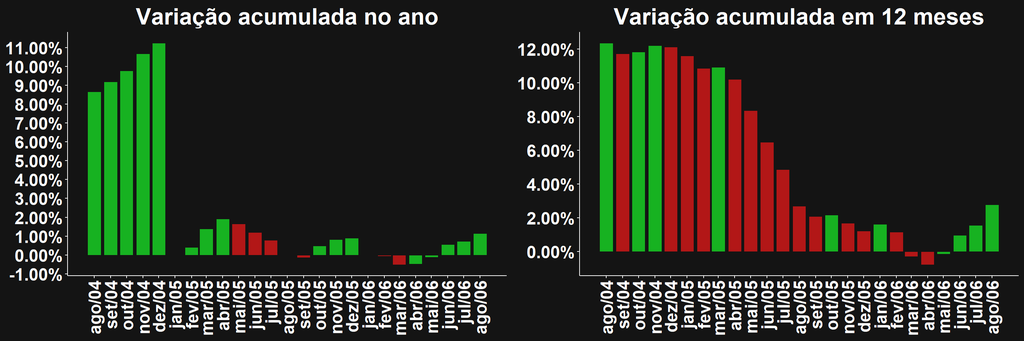

[output not shown]

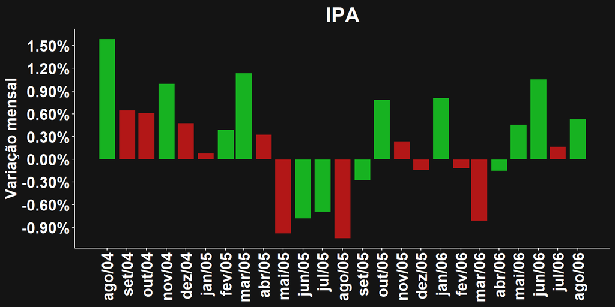

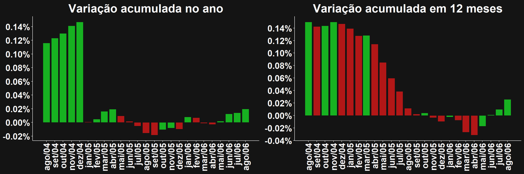

O Indíce de Preços ao Consumidor (IPC), integrante do IGP-DI com peso de 30%, apresentou variação de 0.16% em agosto, valor superior ao mesmo período do ano anterior quando apresentou uma taxa de -0.44%. Com esse resultado o indíce acumula no ano uma variação positiva de 0.19%, e em 12 meses uma variação positiva de 2.4%.

|  | 08/2005 | 07/2006 | 08/2006 |
| --- | --- | --- | --- |
| Variação mensal | -0.44% | 0.06% | 0.16% |
| Variação acumulada no ano | 2.46% | 0.03% | 0.19% |
| Variação acumulada em 12 meses | 4.48% | 1.79% | 2.4% |

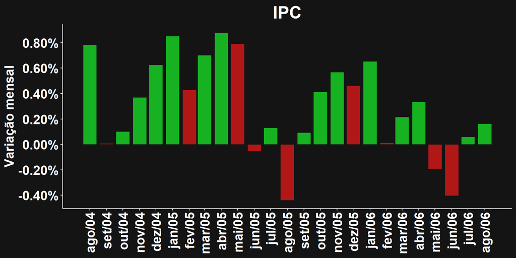

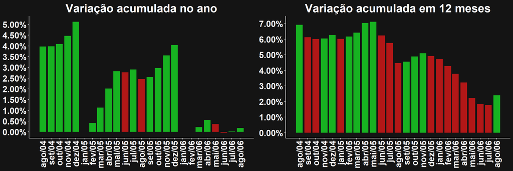

O Indíce Nacional de Custos de Construção (INCC), integrante do IGP-DI com peso de 10%, apresentou variação de 0.24% em agosto, valor superior ao mesmo período do ano anterior quando apresentou uma taxa de 0.02%. Com esse resultado o indíce acumula no ano uma variação positiva de 3.73%, e em 12 meses uma variação positiva de 5.23%.

|  | 08/2005 | 07/2006 | 08/2006 |
| --- | --- | --- | --- |
| Variação mensal | 0.02% | 0.47% | 0.24% |
| Variação acumulada no ano | 4.9% | 3.49% | 3.73% |
| Variação acumulada em 12 meses | 8.88% | 5% | 5.23% |

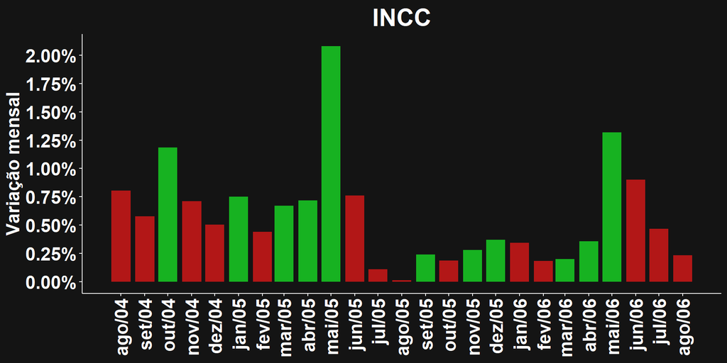

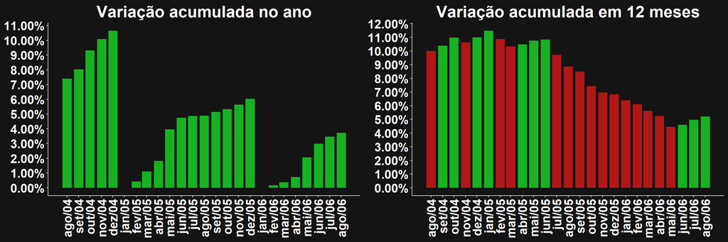

# Estatísticas

As estatísticas descritivas a seguir são feitas com base nos últimos 48 meses, e tem como objetivo possibilitar a avaliação do resultado observado em comparação aos períodos anteriores.

|  | Minimo | 1 Quartil | Mediana | Media | 3 Quartil | Maximo | Desvio Padrão |
| --- | --- | --- | --- | --- | --- | --- | --- |
| IPCA | -0.21% | 0.34% | 0.54% | 0.64% | 0.75% | 3.02% | 0.6% |
| INPC | -0.11% | 0.17% | 0.44% | 0.64% | 0.82% | 3.39% | 0.71% |
| IGP-M | -1% | 0.14% | 0.65% | 0.8% | 1.19% | 5.19% | 1.19% |
| IGP-DI | -0.79% | 0.14% | 0.52% | 0.78% | 1.1% | 5.84% | 1.2% |
| IPA | -1.68% | 0.02% | 0.63% | 0.86% | 1.37% | 7.45% | 1.64% |
| IPC | -0.44% | 0.16% | 0.45% | 0.57% | 0.78% | 3.14% | 0.65% |
| INCC | 0.02% | 0.36% | 0.72% | 0.85% | 1.14% | 2.84% | 0.62% |

Levando em consideração o desvio padrão de cada indíce, proporcionalmente os que mais se afastaram da média foram o INCC, o IPCA e o INPC.

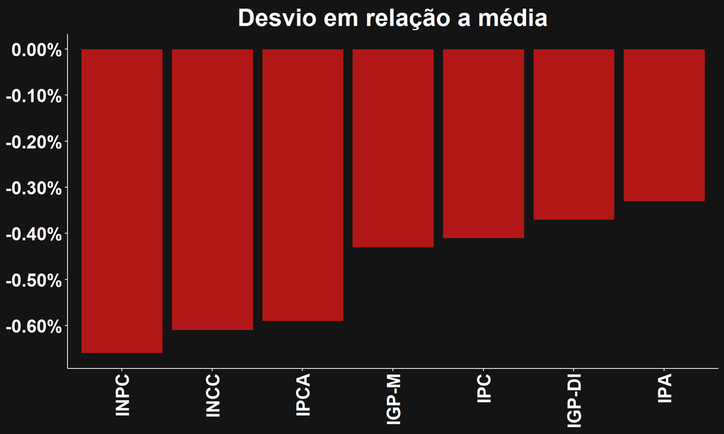

**João Victor Gomes**  
**jvg.santana@gmail.com**  
**[linkedin.com/in/jvictorgomes](https://www.linkedin.com/in/jvictorgomes/)**